# Covid-19 Summary for Middlesex County

2021-04-01

This table summarizes trends in each town in Middlesex County. It is sorted by the category of town as developed in the report [The Five Connecticuts](https://ctdatahaven.org/sites/ctdatahaven/files/UConnCPR%20Changing%20Demographics-5%20CTs%202004.pdf): Urban Core, Urban Periphery, Wealthy, Suburban, and Rural.

For each town it shows the category, the population, the total number of cases to date, the number of recent cases per 100K of population (new cases in the last two weeks), total deaths, and the percentage of total deaths in that town attributed to nursing home residents.

The purpose of this table is to make it easier to quickly scan for trends in local towns.

| town | category | total population | total cases | recent cases per 100K | total deaths | % deaths from nursing homes | town cases | town deaths |
| --- | --- | --- | --- | --- | --- | --- | --- | --- |
| Middletown | Urban Periphery | 46,473 | 3,957 | 460.5 | 136 | 75% |  |  |
| Chester | Suburban | 4,268 | 211 | 117.2 | 15 | 100% |  |  |
| Clinton | Suburban | 12,976 | 943 | 393.0 | 6 | NA |  |  |
| Cromwell | Suburban | 13,973 | 1,124 | 314.9 | 52 | 97% |  |  |
| Durham | Suburban | 7,248 | 551 | 496.7 | 4 | 0% |  |  |
| Essex | Suburban | 6,599 | 396 | 90.9 | 13 | 75% |  |  |
| Haddam | Suburban | 8,267 | 509 | 762.1 | 6 | NA |  |  |
| Killingworth | Suburban | 6,414 | 351 | 249.5 | 6 | NA |  |  |
| Old Saybrook | Suburban | 10,118 | 828 | 247.1 | 60 | 95% |  |  |
| Deep River | Rural | 4,493 | 286 | 356.1 | 1 | NA |  |  |
| East Haddam | Rural | 9,032 | 407 | 199.3 | 18 | 0% |  |  |
| East Hampton | Rural | 12,856 | 744 | 287.8 | 20 | NA |  |  |
| Middlefield | Rural | 4,385 | 241 | 273.7 | 0 | NA |  |  |
| Portland | Rural | 9,362 | 572 | 288.4 | 17 | 64% |  |  |
| Westbrook | Rural | 6,904 | 492 | 304.2 | 3 | NA |  |  |

The first map shows cases by town in Middlesex County. The second map shows the percentage of individuals below the poverty line.

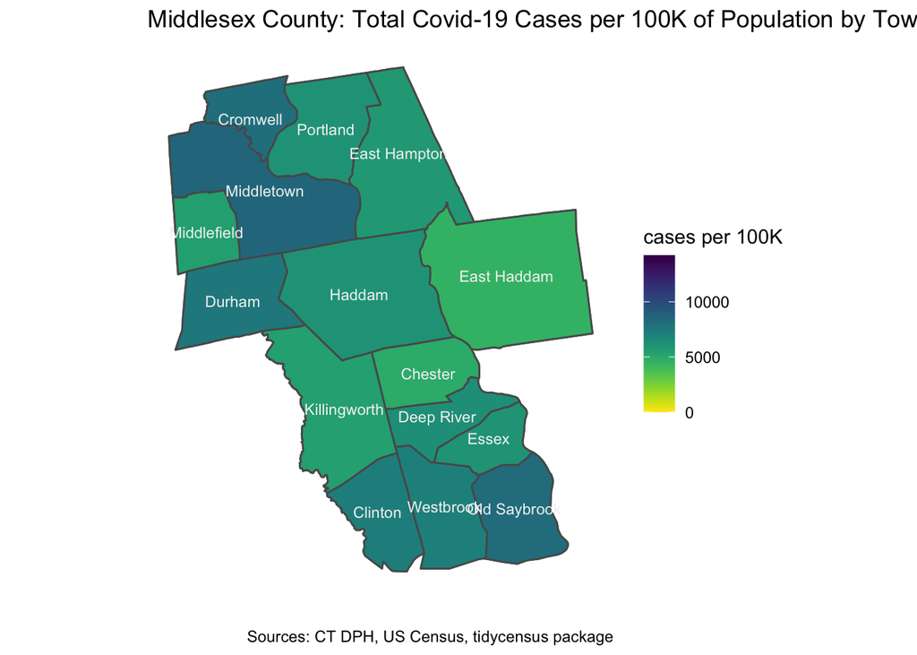

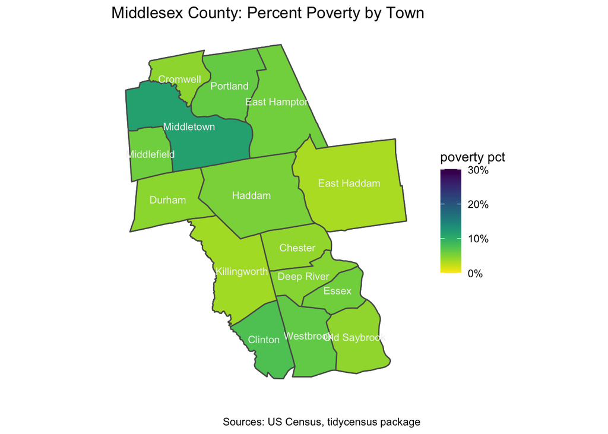